# Probability 2: Loaded dice

## Exercise 7:

Given a 6-sided fair dice you try a new game. You only throw the dice a second time if the result of the first throw is **lower** or equal to 3. Which of the following `probability mass functions` will be the one you should get given this new constraint?

Hints:

- You can simulate the second throws as a numpy array and then make the values that met a certain criteria equal to 0 by using [np.where](https://numpy.org/doc/stable/reference/generated/numpy.where.html)

```
[Text(0.5, 1.0, 'Histogram of 20000 rolls (dependant sum of rolling twice)')]
```

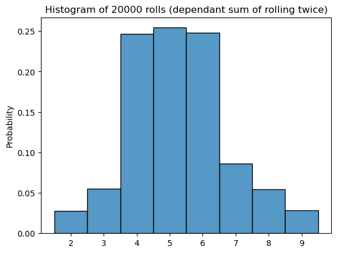

```python
# You can use this cell for your calculations (not graded)
n_rolls = 20_000

n_sides = 6

# Represent a dice by using a numpy array
dice = np.array([i for i in range(1, n_sides+1)])

first_rolls = np.array([np.random.choice(dice) for _ in range(n_rolls)])

second_rolls = np.array([np.random.choice(dice) for _ in range(n_rolls)])

second_rolls = np.where(first_rolls<=3, second_rolls, 0)

sum_of_rolls = first_rolls + second_rolls

dependant_rolls_hist = sns.histplot(sum_of_rolls, stat = "probability", discrete=True)
dependant_rolls_hist.set(title=f"Histogram of {n_rolls} rolls (dependant sum of rolling twice)")
```

```python
# Run this cell to submit your answer
utils.exercise_7()
```

```
ToggleButtons(description='Your answer:', options=('left-most', 'left-center', 'right-center', 'right-most'), …
```

```
Button(button_style='success', description='Save your answer!', style=ButtonStyle())
```

```
Output()
```

## Exercise 8:

Given the same scenario as in the previous exercise but with the twist that you only throw the dice a second time if the result of the first throw is **greater** or equal to 3. Which of the following `probability mass functions` will be the one you should get given this new constraint?

```
[Text(0.5, 1.0, 'Histogram of 20000 rolls (dependant sum of rolling twice)')]
```

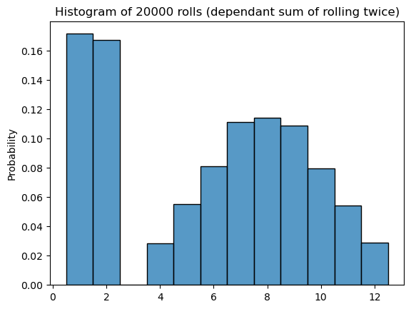

```python
# You can use this cell for your calculations (not graded)

n_rolls = 20_000

n_sides = 6

# Represent a dice by using a numpy array
dice = np.array([i for i in range(1, n_sides+1)])

first_rolls = np.array([np.random.choice(dice) for _ in range(n_rolls)])

second_rolls = np.array([np.random.choice(dice) for _ in range(n_rolls)])

second_rolls = np.where(first_rolls>=3, second_rolls, 0)

sum_of_rolls = first_rolls + second_rolls

dependant_rolls_hist = sns.histplot(sum_of_rolls, stat = "probability", discrete=True)
dependant_rolls_hist.set(title=f"Histogram of {n_rolls} rolls (dependant sum of rolling twice)")
```

```python
# Run this cell to submit your answer
utils.exercise_8()
```

```
ToggleButtons(description='Your answer:', options=('left-most', 'left-center', 'right-center', 'right-most'), …
```

```
Button(button_style='success', description='Save your answer!', style=ButtonStyle())
```

```
Output()
```

## Exercise 9:

Given a n-sided fair dice. You throw it twice and record the sum. How does increasing the number of sides `n` of the dice impact the mean and variance of the sum and the covariance of the joint distribution?

```python
# You can use this cell for your calculations (not graded)
n_rolls = 20_000

n_sides = 6

# Represent a dice by using a numpy array
dice = np.array([i for i in range(1, n_sides+1)])

first_rolls = np.array([np.random.choice(dice) for _ in range(n_rolls)])

second_rolls = np.array([np.random.choice(dice) for _ in range(n_rolls)])


sum_of_rolls = first_rolls + second_rolls

print(f"mean of first_rolls: {np.mean(first_rolls):.2f}\nvariance of first_rolls: {np.var(first_rolls):.2f}\n")
print(f"mean of second_rolls: {np.mean(second_rolls):.2f}\nvariance of second_rolls: {np.var(second_rolls):.2f}\n")
print(f"mean of sum_of_rolls: {np.mean(sum_of_rolls):.2f}\nvariance of sum_of_rolls: {np.var(sum_of_rolls):.2f}\n")
print(f"covariance between first and second roll:\n{np.cov(first_rolls, second_rolls)}")
```

```
mean of first_rolls: 3.49
variance of first_rolls: 2.90

mean of second_rolls: 3.50
variance of second_rolls: 2.93

mean of sum_of_rolls: 6.99
variance of sum_of_rolls: 5.85

covariance between first and second roll:
[[2.90046006 0.0095396 ]
 [0.0095396  2.93494611]]
```

```python
n_rolls = 20_000

n_sides = 20

# Represent a dice by using a numpy array
dice = np.array([i for i in range(1, n_sides+1)])

first_rolls = np.array([np.random.choice(dice) for _ in range(n_rolls)])

second_rolls = np.array([np.random.choice(dice) for _ in range(n_rolls)])


sum_of_rolls = first_rolls + second_rolls

print(f"mean of first_rolls: {np.mean(first_rolls):.2f}\nvariance of first_rolls: {np.var(first_rolls):.2f}\n")
print(f"mean of second_rolls: {np.mean(second_rolls):.2f}\nvariance of second_rolls: {np.var(second_rolls):.2f}\n")
print(f"mean of sum_of_rolls: {np.mean(sum_of_rolls):.2f}\nvariance of sum_of_rolls: {np.var(sum_of_rolls):.2f}\n")
print(f"covariance between first and second roll:\n{np.cov(first_rolls, second_rolls)}")
```

```
mean of first_rolls: 10.51
variance of first_rolls: 33.61

mean of second_rolls: 10.46
variance of second_rolls: 33.17

mean of sum_of_rolls: 20.97
variance of sum_of_rolls: 66.95

covariance between first and second roll:
[[33.61583679  0.08216771]
 [ 0.08216771 33.17012667]]
```

```python
# Run this cell to submit your answer
utils.exercise_9()
```

```
As the number of sides in the die increases:
```

```
ToggleButtons(description='The mean of the sum:', options=('stays the same', 'increases', 'decreases'), value=…
```

```
ToggleButtons(description='The variance of the sum:', options=('stays the same', 'increases', 'decreases'), va…
```

```
ToggleButtons(description='The covariance of the joint distribution:', options=('stays the same', 'increases',…
```

```
Button(button_style='success', description='Save your answer!', style=ButtonStyle())
```

```
Output()
```

## Exercise 10:

Given a 6-sided loaded dice. You throw it twice and record the sum. Which of the following statemets is true?

```python
# You can use this cell for your calculations (not graded)
n_rolls = 20_000

n_sides = 6

# Represent a dice by using a numpy array
dice = np.array([i for i in range(1, n_sides+1)])

first_rolls = np.array([np.random.choice(dice) for _ in range(n_rolls)])

second_rolls = np.array([np.random.choice(dice) for _ in range(n_rolls)])


sum_of_rolls = first_rolls + second_rolls

print(f"mean of first_rolls: {np.mean(first_rolls):.2f}\nvariance of first_rolls: {np.var(first_rolls):.2f}\n")
print(f"mean of second_rolls: {np.mean(second_rolls):.2f}\nvariance of second_rolls: {np.var(second_rolls):.2f}\n")
print(f"mean of sum_of_rolls: {np.mean(sum_of_rolls):.2f}\nvariance of sum_of_rolls: {np.var(sum_of_rolls):.2f}\n")
print(f"covariance between first and second roll:\n{np.cov(first_rolls, second_rolls)}")
```

```
mean of first_rolls: 3.52
variance of first_rolls: 2.93

mean of second_rolls: 3.50
variance of second_rolls: 2.89

mean of sum_of_rolls: 7.02
variance of sum_of_rolls: 5.79

covariance between first and second roll:
[[ 2.92704683 -0.01443326]
 [-0.01443326  2.8941411 ]]
```

[output not shown]

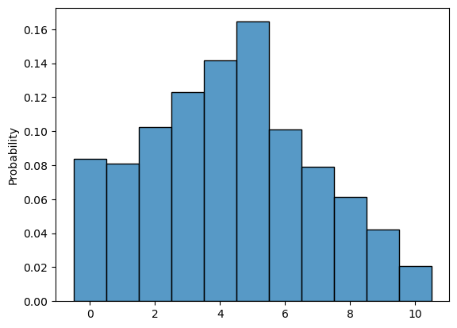

```python
dice =6

probs_loaded_dice = load_dice(dice, 1)

n_rolls = 20000

first_rolls = np.array([np.random.choice(dice, p=probs_loaded_dice) for _ in range(n_rolls)])
second_rolls = np.array([np.random.choice(dice, p=probs_loaded_dice) for _ in range(n_rolls)])

sum_of_rolls = first_rolls + second_rolls

sum_2_rolls_pdf = sns.histplot(sum_of_rolls, stat = "probability", discrete = True)

print(f"mean of first_rolls: {np.mean(first_rolls):.2f}\nvariance of first_rolls: {np.var(first_rolls):.2f}\n")
print(f"mean of second_rolls: {np.mean(second_rolls):.2f}\nvariance of second_rolls: {np.var(second_rolls):.2f}\n")
print(f"mean of sum_of_rolls: {np.mean(sum_of_rolls):.2f}\nvariance of sum_of_rolls: {np.var(sum_of_rolls):.2f}\n")
print(f"covariance between first and second roll:\n{np.cov(first_rolls, second_rolls)}")
```

[output not shown]

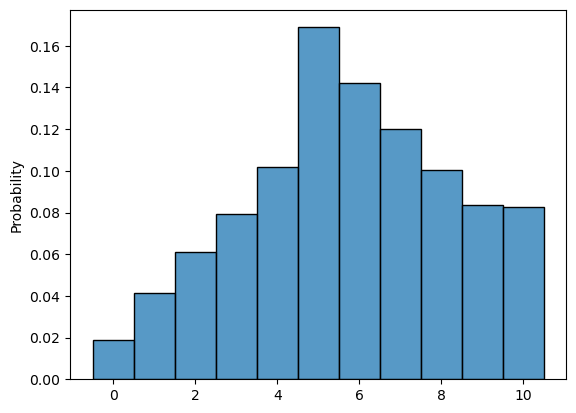

```python
dice =6

probs_loaded_dice = load_dice(dice, 6)

n_rolls = 20000

first_rolls = np.array([np.random.choice(dice, p=probs_loaded_dice) for _ in range(n_rolls)])
second_rolls = np.array([np.random.choice(dice, p=probs_loaded_dice) for _ in range(n_rolls)])

sum_of_rolls = first_rolls + second_rolls

sum_2_rolls_pdf = sns.histplot(sum_of_rolls, stat = "probability", discrete = True)

print(f"mean of first_rolls: {np.mean(first_rolls):.2f}\nvariance of first_rolls: {np.var(first_rolls):.2f}\n")
print(f"mean of second_rolls: {np.mean(second_rolls):.2f}\nvariance of second_rolls: {np.var(second_rolls):.2f}\n")
print(f"mean of sum_of_rolls: {np.mean(sum_of_rolls):.2f}\nvariance of sum_of_rolls: {np.var(sum_of_rolls):.2f}\n")
print(f"covariance between first and second roll:\n{np.cov(first_rolls, second_rolls)}")
```

```python
# Run this cell to submit your answer
utils.exercise_10()
```

```
RadioButtons(layout=Layout(width='max-content'), options=('the mean and variance is the same regardless of whi…
```

```
Button(button_style='success', description='Save your answer!', style=ButtonStyle())
```

```
Output()
```

## Exercise 11:

Given a fair n-sided dice. You throw it twice and record the sum but the second throw depends on the result of the first one such as in exercises 7 and 8. Which of the following statements is true?

```python
# You can use this cell for your calculations (not graded)

n_rolls = 20_000

n_sides = 20

# Represent a dice by using a numpy array
dice = np.array([i for i in range(1, n_sides+1)])

first_rolls = np.array([np.random.choice(dice) for _ in range(n_rolls)])

second_rolls = np.array([np.random.choice(dice) for _ in range(n_rolls)])

second_rolls = np.where(first_rolls<=3, second_rolls, 0)

sum_of_rolls = first_rolls + second_rolls

print(f"mean of first_rolls: {np.mean(first_rolls):.2f}\nvariance of first_rolls: {np.var(first_rolls):.2f}\n")
print(f"mean of second_rolls: {np.mean(second_rolls):.2f}\nvariance of second_rolls: {np.var(second_rolls):.2f}\n")
print(f"mean of sum_of_rolls: {np.mean(sum_of_rolls):.2f}\nvariance of sum_of_rolls: {np.var(sum_of_rolls):.2f}\n")
print(f"covariance between first and second roll:\n{np.cov(first_rolls, second_rolls)}")
```

```
mean of first_rolls: 10.51
variance of first_rolls: 33.41

mean of second_rolls: 1.62
variance of second_rolls: 19.73

mean of sum_of_rolls: 12.13
variance of sum_of_rolls: 25.63

covariance between first and second roll:
[[ 33.40980808 -13.75539615]
 [-13.75539615  19.72802698]]
```

```python
# Run this cell to submit your answer
utils.exercise_11()
```

```
RadioButtons(layout=Layout(width='max-content'), options=('changing the direction of the inequality will chang…
```

```
Button(button_style='success', description='Save your answer!', style=ButtonStyle())
```

```
Output()
```

## Exercise 12:

Given a n-sided dice (could be fair or not). You throw it twice and record the sum (there is no dependance between the throws). If you are only given the histogram of the sums can you use it to know which are the probabilities of the dice landing on each side?

In other words, if you are provided with only the histogram of the sums like this one:

[figure not shown]

Could you use it to know the probabilities of the dice landing on each side? Which will be equivalent to finding this histogram:

[figure not shown]

```python
# You can use this cell for your calculations (not graded)
```

```python
# Run this cell to submit your answer
utils.exercise_12()
```

```
RadioButtons(layout=Layout(width='max-content'), options=('yes, but only if one of the sides is loaded', 'no, …
```

```
Button(button_style='success', description='Save your answer!', style=ButtonStyle())
```

```
Output()
```

## Before Submitting Your Assignment

Run the next cell to check that you have answered all of the exercises

```python
utils.check_submissions()
```

```
All answers saved, you can submit the assignment for grading!
```

**Congratulations on finishing this assignment!**

During this assignment you tested your knowledge on probability distributions, descriptive statistics and visual interpretation of these concepts. You had the choice to compute everything analytically or create simulations to assist you get the right answer. You probably also realized that some exercises could be answered without any computations just by looking at certain hidden queues that the visualizations revealed.

**Keep up the good work!**